# Football Performance and Economic Dynamics Across the Top Five European Leagues

### Introduction to Coding and Data Management part 2 - Matteo Fozzato

### Introduction: Modern Football's Landscape

In recent years, football has experienced a remarkable transformation, both on and off the pitch, particularly in Europe’s top five leagues: the English Premier League (EPL), La Liga (Spain), Serie A (Italy), Bundesliga (Germany), and Ligue 1 (France). These leagues have not only captured global attention due to the quality of play and star-studded teams but have also become economic powerhouses, driving significant revenue through broadcasting rights, sponsorships, and merchandising.

The Premier League, for instance, has consistently led the way in revenue generation, largely due to lucrative television deals and its broad international fan base. Meanwhile, La Liga has showcased its unique brand of football, highlighted by the success of clubs like FC Barcelona and Real Madrid, which have global appeal. Serie A, after a period of decline, has seen a resurgence with increased investment and the return of top-tier talent. The Bundesliga, known for its fan-friendly policies and financial prudence, continues to produce competitive teams and nurturing young talent. Ligue 1, although traditionally seen as a feeder league, has gained prominence with clubs like Paris Saint-Germain making substantial investments to bring in world-class players.

However, these leagues also face challenges, including financial disparities among clubs, the impact of the COVID-19 pandemic on matchday revenues, and the growing influence of wealthy owners. As football continues to globalize, these top leagues strive to balance sporting excellence with sustainable economic models, ensuring the long-term health of the sport.

### Research purpose

- Analyzing the performance on the pitch of clubs (and whole leagues) across Europe's top 5 leagues
- Analyizing the financial situation across the top 5 leagues
- Analyzing the correlation between sport performance and economic parameters
- Getting insights about players, both about performance and finances

All of the steps of the notebook will be oriented towards fulfilling these pruposes.

### Project overview

The project will be divided in four parts:

- Part 1: Installing and importing necessary libraries
- Part 2: Data cleaning
- Part 3: Data combining and reshaping
- Part 4: Data analisys and visualization

### Datasets

- club.csv: https://www.kaggle.com/datasets/sanjeetsinghnaik/football-club-market-value-2021
- raw_wages1.csv: https://www.kaggle.com/datasets/ultimus/football-salaries-dataset?select=raw_wages.csv
- players.csv: https://www.kaggle.com/datasets/sanjeetsinghnaik/most-expensive-footballers-2021
- UCL_AllTime_Performance_Table.csv: https://www.kaggle.com/datasets/fardifaalam170041060/champions-league-dataset-1955-2023

These are the four datasets which will be used throughout the notebook.

## Part 1 - Installing and importing necessary libraries

```python
%pip install pandas numpy matplotlib seaborn plotly altair geopandas scipy
```

Now I need to import them in order to use their functions.

```python
import pandas as pd  # Data manipulation and analysis library

import numpy as np  # Numerical computing library

import matplotlib.pyplot as plt  # Plotting library

import seaborn as sns  # Statistical data visualization library (built on top of matplotlib)

import plotly.express as px  # Library for creating interactive plots and charts

import re  # Regular expressions library for pattern matching and string manipulation

import altair as alt  # Declarative statistical visualization library

import geopandas as gpd  # Library for working with geospatial data

from scipy.stats import pearsonr, f_oneway  # Statistical functions for correlation and ANOVA tests

import warnings  # Warning control library
warnings.filterwarnings('ignore')  # This suppresses unwanted warnings
```

## Part 2: Data cleaning

### First dataset - clubs

This first dataset contains information about clubs in Europe in 2021.

```python
clubs_df = pd.read_csv('club.csv')
print(clubs_df[:10].to_string())
```

```
   Unnamed: 0            Club Name Competition Name  Squad Size  Average Age Of Players  Market Value Of Club In Millions(£)  Average Market Value Of Players In Millions(£)  Market Value Of Top 18 Players In Millions(£)
0           0      Manchester City   Premier League          24                    27.1                               970.02                                           40.42                                         920.70
1           1  Paris Saint-Germain          Ligue 1          36                    26.1                               891.18                                           24.76                                         801.00
2           2    Manchester United   Premier League          29                    27.9                               820.13                                           28.28                                         742.50
3           3           Chelsea FC   Premier League          27                    26.9                               802.35                                           29.72                                         737.10
4           4         Liverpool FC   Premier League          27                    27.2                               779.85                                           28.88                                         715.95
5           5        Bayern Munich       Bundesliga          26                    26.1                               756.45                                           29.09                                         726.21
6           6          Real Madrid           LaLiga          27                    27.3                               680.40                                           25.20                                         610.20
7           7   Atlético de Madrid           LaLiga          22                    28.2                               671.31                                           30.51                                         651.60
8           8    Tottenham Hotspur   Premier League          24                    25.6                               627.30                                           26.14                                         558.00
9           9         FC Barcelona           LaLiga          30                    25.9                               592.20                                           19.74                                         535.50
```

As first thing, I am going to remove the Unnamed column, which is useless to my purpose.

```python
# Drop the "Unnamed: 0" column
clubs1 = clubs_df.drop(columns=['Unnamed: 0'])

print(clubs1[:10].to_string())
```

```
             Club Name Competition Name  Squad Size  Average Age Of Players  Market Value Of Club In Millions(£)  Average Market Value Of Players In Millions(£)  Market Value Of Top 18 Players In Millions(£)
0      Manchester City   Premier League          24                    27.1                               970.02                                           40.42                                         920.70
1  Paris Saint-Germain          Ligue 1          36                    26.1                               891.18                                           24.76                                         801.00
2    Manchester United   Premier League          29                    27.9                               820.13                                           28.28                                         742.50
3           Chelsea FC   Premier League          27                    26.9                               802.35                                           29.72                                         737.10
4         Liverpool FC   Premier League          27                    27.2                               779.85                                           28.88                                         715.95
5        Bayern Munich       Bundesliga          26                    26.1                               756.45                                           29.09                                         726.21
6          Real Madrid           LaLiga          27                    27.3                               680.40                                           25.20                                         610.20
7   Atlético de Madrid           LaLiga          22                    28.2                               671.31                                           30.51                                         651.60
8    Tottenham Hotspur   Premier League          24                    25.6                               627.30                                           26.14                                         558.00
9         FC Barcelona           LaLiga          30                    25.9                               592.20                                           19.74                                         535.50
```

Then, I am going to convert the currency of the dataset and chenge the name of the columns, in order to be more familiar with the results of the future analysis.

```python
# Define the conversion rate
conversion_rate = 1.17

# Identify the columns to convert
columns_to_convert = [
    'Market Value Of Club In Millions(£)',
    'Average Market Value Of Players In Millions(£)',
    'Market Value Of Top 18 Players In Millions(£)'
]

# Convert the values from £ to €
for column in columns_to_convert:
    clubs1[column] = clubs1[column] * conversion_rate

# Optionally, you can rename the columns to reflect the new currency
clubs1 = clubs1.rename(columns={
    'Market Value Of Club In Millions(£)': 'Market Value Of Club In Millions(€)',
    'Average Market Value Of Players In Millions(£)': 'Average Market Value Of Players In Millions(€)',
    'Market Value Of Top 18 Players In Millions(£)': 'Market Value Of Top 18 Players In Millions(€)'
})

# Check the first few rows to confirm the conversion
print(clubs1[:10].to_string())
```

```
             Club Name Competition Name  Squad Size  Average Age Of Players  Market Value Of Club In Millions(€)  Average Market Value Of Players In Millions(€)  Market Value Of Top 18 Players In Millions(€)
0      Manchester City   Premier League          24                    27.1                            1134.9234                                         47.2914                                      1077.2190
1  Paris Saint-Germain          Ligue 1          36                    26.1                            1042.6806                                         28.9692                                       937.1700
2    Manchester United   Premier League          29                    27.9                             959.5521                                         33.0876                                       868.7250
3           Chelsea FC   Premier League          27                    26.9                             938.7495                                         34.7724                                       862.4070
4         Liverpool FC   Premier League          27                    27.2                             912.4245                                         33.7896                                       837.6615
5        Bayern Munich       Bundesliga          26                    26.1                             885.0465                                         34.0353                                       849.6657
6          Real Madrid           LaLiga          27                    27.3                             796.0680                                         29.4840                                       713.9340
7   Atlético de Madrid           LaLiga          22                    28.2                             785.4327                                         35.6967                                       762.3720
8    Tottenham Hotspur   Premier League          24                    25.6                             733.9410                                         30.5838                                       652.8600
9         FC Barcelona           LaLiga          30                    25.9                             692.8740                                         23.0958                                       626.5350
```

As the focus of the project are the top 5 leagues, I am going to filter the dataset to only keep clubs who participate in those competitions.

```python
# Define the top 5 leagues
top_5_leagues = [
    'Premier League',  # England
    'LaLiga',                 # Spain
    'Bundesliga',              # Germany
    'Serie A',                 # Italy
    'Ligue 1'                  # France
]

# Filter the DataFrame
clubs5 = clubs1[clubs1['Competition Name'].isin(top_5_leagues)]

# Sort the DataFrame by the "Competition Name" "Market Value Of Club In Millions(€)" and column
clubs1.sort_values(by=['Competition Name', 'Market Value Of Club In Millions(€)'], inplace=True)

print(clubs5[:10].to_string())
```

```
             Club Name Competition Name  Squad Size  Average Age Of Players  Market Value Of Club In Millions(€)  Average Market Value Of Players In Millions(€)  Market Value Of Top 18 Players In Millions(€)
0      Manchester City   Premier League          24                    27.1                            1134.9234                                         47.2914                                      1077.2190
1  Paris Saint-Germain          Ligue 1          36                    26.1                            1042.6806                                         28.9692                                       937.1700
2    Manchester United   Premier League          29                    27.9                             959.5521                                         33.0876                                       868.7250
3           Chelsea FC   Premier League          27                    26.9                             938.7495                                         34.7724                                       862.4070
4         Liverpool FC   Premier League          27                    27.2                             912.4245                                         33.7896                                       837.6615
5        Bayern Munich       Bundesliga          26                    26.1                             885.0465                                         34.0353                                       849.6657
6          Real Madrid           LaLiga          27                    27.3                             796.0680                                         29.4840                                       713.9340
7   Atlético de Madrid           LaLiga          22                    28.2                             785.4327                                         35.6967                                       762.3720
8    Tottenham Hotspur   Premier League          24                    25.6                             733.9410                                         30.5838                                       652.8600
9         FC Barcelona           LaLiga          30                    25.9                             692.8740                                         23.0958                                       626.5350
```

### Second dataset - raw wages

This second dataset is about players all over the world and their salaries.

```python
wages_raw_1= pd.read_csv('raw_wages1.csv')

print(wages_raw_1[:10].to_string())
```

```
                               Name                                       Club                                              Division                                                      Based    Nat    EU National   Caps    AT Apps            Position   Age        CR        Begins       Expires     …
0   Cristiano Ronaldo - Portuguese    Al-Nassr (KSA) - Roshn Saudi League        Roshn Saudi League                                    Saudi Arabia (Saudi Pro League)                            POR    Yes           200.0   673        ST (C)             38.0   7,629     31/12/2022    30/6/2025       …
1   Karim Benzema - French            Al-Ittihad - Roshn Saudi League            Roshn Saudi League                                    Saudi Arabia (Saudi Pro League)                            FRA    Yes            97.0   555        ST (C)             35.0   8,250     1/7/2023      30/6/2025       …
2   Neymar - Brazilian                Al-Hilal (KSA) - Roshn Saudi League        Roshn Saudi League                                    Saudi Arabia (Saudi Pro League)                            BRA    Yes           124.0   340        AM (LC), ST (C)    31.0   9,000     15/8/2023     30/6/2025     Pa…
3   Ezri Konsa - English              Al-Hilal (KSA) - Roshn Saudi League        Roshn Saudi League                                    Saudi Arabia (Saudi Pro League)                            ENG    No              0.0   245        D (C)              25.0   7,414     27/8/2023     30/6/2027     As…
4   Kylian Mbappé - French            Paris Saint-Germain - Ligue 1 Uber Eats    Ligue 1 Uber Eats                                     France (Ligue 1)                                           FRA    Yes            70.0   221        AM (RL), ST (C)    24.0   9,415     22/7/2023     30/6/2028     Mo…
5   Sadio Mané - Senegalese           Al-Nassr (KSA) - Roshn Saudi League        Roshn Saudi League                                    Saudi Arabia (Saudi Pro League)                            SEN    No             93.0   377        AM (RLC), ST (C)   31.0   7,488     1/8/2023      30/6/2027     Ba…
6   Marcelo Brozović - Croatian       Al-Nassr (KSA) - Roshn Saudi League        Roshn Saudi League                                    Saudi Arabia (Saudi Pro League)                            CRO    Yes            87.0   392        DM, M (C)          30.0   7,750     3/7/2023      30/6/2026     In…
7   Kalidou Koulibaly - Senegalese    Al-Hilal (KSA) - Roshn Saudi League        Roshn Saudi League                                    Saudi Arabia (Saudi Pro League)                            SEN    Yes            70.0   367        D (C)              32.0   7,500     1/7/2023      30/6/2026     Ch…
8   N'Golo Kanté - French             Al-Ittihad - Roshn Saudi League            Roshn Saudi League                                    Saudi Arabia (Saudi Pro League)                            FRA    Yes            53.0   361        DM, M (C)          32.0   8,000     19/6/2023     30/6/2026     Ch…
9   - -                               -                                          Roshn Saudi League                                    Saudi Arabia (Saudi Pro League)                            SRB    No             81.0   378                           28.0   7,495     19/8/2023     30/6/2026     Fu…
```

Since I don't need information about the contract, name or nationality of the players, I will only select the following columns.

```python
# Step 1: Select only the desired columns
wages_filtered = wages_raw_1.loc[:, ['Division', 'Caps', 'Last Trans. Fee', 'Salary']]


# Step 2: Check the first few rows to confirm the selection
print(wages_filtered[:20].to_string())
```

```
                                                Division   Caps    Last Trans. Fee              Salary
0    Roshn Saudi League                                   200.0   -                  €203,478,000 p/a
1    Roshn Saudi League                                    97.0   -                  €199,452,000 p/a
2    Roshn Saudi League                                   124.0   €90M               €149,589,000 p/a
3    Roshn Saudi League                                     0.0   €55M               €74,157,000 p/a
4    Ligue 1 Uber Eats                                     70.0   €186M              €48,467,000 p/a
5    Roshn Saudi League                                    93.0   €28M               €40,977,000 p/a
6    Roshn Saudi League                                    87.0   €18M               €35,864,000 p/a
7    Roshn Saudi League                                    70.0   €25M               €29,918,000 p/a
8    Roshn Saudi League                                    53.0   €0                 €25,624,000 p/a
9    Roshn Saudi League                                    81.0   €50M               €24,931,000 p/a
10   Roshn Saudi League                                    29.0   €46.5M             €24,931,000 p/a
11   Roshn Saudi League                                    41.0   €55M               €24,835,000 p/a
12   Roshn Saudi League                                    22.0   €27.5M             €24,791,000 p/a
13   LALIGA EA SPORTS                                     105.0   €28M               €24,233,000 p/a
14   Roshn Saudi League                                    77.0   €14M               €22,741,000 p/a
15   Premier League                                        21.0   €41M               €22,733,000 p/a
16   LALIGA EA SPORTS                                     101.0   €0                 €22,438,000 p/a
17   Roshn Saudi League                                    61.0   €12.5M             €21,940,000 p/a
18   Bundesliga                                            84.0   €100M              €21,940,000 p/a
19   LALIGA EA SPORTS                                     166.0   €33M               €21,740,000 p/a
```

There are a few problems with the column 'Last Trans. Fee'. It has many string parts and the numbers are inidcated with M (millions) or K(thousands); I will need to keep only numbers and convert them based on the letter they are followed by.

```python
# Function to convert fee values
def convert_fee(fee):
    if pd.isna(fee):  # Check for NaN or None values
        return np.nan
    if isinstance(fee, str):
        # Remove any surrounding whitespace and currency symbols
        fee = fee.strip().replace('€', '')

        # Use regex to find the numerical part and the letter
        match = re.match(r'(\d+\.?\d*)([MK]?)', fee)
        if match:
            number, unit = match.groups()
            number = float(number) if number else 0
            if unit == 'M':
                return number * 1_000_000
            elif unit == 'K':
                return number * 1_000
            else:
                return number
    return np.nan

# Apply the conversion function to the "Last Trans. Fee" column
wages_filtered['Last Trans. Fee'] = wages_filtered['Last Trans. Fee'].apply(convert_fee)

# Check the updated column
print(wages_filtered[['Last Trans. Fee']])
```

```
       Last Trans. Fee
0                  NaN
1                  NaN
2           90000000.0
3           55000000.0
4          186000000.0
...                ...
40786              NaN
40787              NaN
40788              NaN
40789              0.0
40790              NaN

[40791 rows x 1 columns]
```

The column 'Salary' also needs to be cleaned of the string characters.

```python
# Step 1: Remove non-numeric characters and convert to numeric
wages_filtered['Salary'] = wages_filtered['Salary'].str.replace(r'[^\d.]', '', regex=True)

# Step 2: Convert the cleaned strings to numeric values
wages_filtered['Salary'] = pd.to_numeric(wages_filtered['Salary'])

# Step 3: Check the first few rows to confirm the changes
print(wages_filtered[:15].to_string())
```

```
                                                Division   Caps  Last Trans. Fee     Salary
0    Roshn Saudi League                                   200.0              NaN  203478000
1    Roshn Saudi League                                    97.0              NaN  199452000
2    Roshn Saudi League                                   124.0       90000000.0  149589000
3    Roshn Saudi League                                     0.0       55000000.0   74157000
4    Ligue 1 Uber Eats                                     70.0      186000000.0   48467000
5    Roshn Saudi League                                    93.0       28000000.0   40977000
6    Roshn Saudi League                                    87.0       18000000.0   35864000
7    Roshn Saudi League                                    70.0       25000000.0   29918000
8    Roshn Saudi League                                    53.0              0.0   25624000
9    Roshn Saudi League                                    81.0       50000000.0   24931000
10   Roshn Saudi League                                    29.0       46500000.0   24931000
11   Roshn Saudi League                                    41.0       55000000.0   24835000
12   Roshn Saudi League                                    22.0       27500000.0   24791000
13   LALIGA EA SPORTS                                     105.0       28000000.0   24233000
14   Roshn Saudi League                                    77.0       14000000.0   22741000
```

Now, I will rename the columns so the datasets are as uniform as possible.

```python
#Step 1: Rename the columns
wages_filtered = wages_filtered.rename(columns={
    'Division': 'Competition Name',
    'Caps': 'Appearences',
    'Last Trans. Fee': 'Transfer Fee (€)',
    'Salary': 'Salary (€)'
})

# Step 2: Check the first few rows to confirm the renaming
print(wages_filtered[:15].to_string())
```

```
                                        Competition Name  Appearences  Transfer Fee (€)  Salary (€)
0    Roshn Saudi League                                         200.0               NaN   203478000
1    Roshn Saudi League                                          97.0               NaN   199452000
2    Roshn Saudi League                                         124.0        90000000.0   149589000
3    Roshn Saudi League                                           0.0        55000000.0    74157000
4    Ligue 1 Uber Eats                                           70.0       186000000.0    48467000
5    Roshn Saudi League                                          93.0        28000000.0    40977000
6    Roshn Saudi League                                          87.0        18000000.0    35864000
7    Roshn Saudi League                                          70.0        25000000.0    29918000
8    Roshn Saudi League                                          53.0               0.0    25624000
9    Roshn Saudi League                                          81.0        50000000.0    24931000
10   Roshn Saudi League                                          29.0        46500000.0    24931000
11   Roshn Saudi League                                          41.0        55000000.0    24835000
12   Roshn Saudi League                                          22.0        27500000.0    24791000
13   LALIGA EA SPORTS                                           105.0        28000000.0    24233000
14   Roshn Saudi League                                          77.0        14000000.0    22741000
```

I will filter the dataset to only keep players in the top 5 leagues.

```python
# Strip any leading/trailing spaces just to be sure
wages_filtered['Competition Name'] = wages_filtered['Competition Name'].str.strip()

# Define the top 5 leagues
top_5_leagues = [
    'Premier League',       # England
    'LALIGA EA SPORTS',     # Spain
    'Bundesliga',           # Germany
    'Serie A TIM',          # Italy
    'Ligue 1 Uber Eats'     # France,

]

# Filter the DataFrame to include only the top 5 leagues
wages_filtered = wages_filtered[wages_filtered['Competition Name'].isin(top_5_leagues)]

# Check the filtered DataFrame
print(wages_filtered[:15].to_string())
```

```
     Competition Name  Appearences  Transfer Fee (€)  Salary (€)
4   Ligue 1 Uber Eats         70.0       186000000.0    48467000
13   LALIGA EA SPORTS        105.0        28000000.0    24233000
15     Premier League         21.0        41000000.0    22733000
16   LALIGA EA SPORTS        101.0               0.0    22438000
18         Bundesliga         84.0       100000000.0    21940000
19   LALIGA EA SPORTS        166.0        33000000.0    21740000
20     Premier League         82.0        55000000.0    21225000
21     Premier League         89.0        40000000.0    21225000
22   LALIGA EA SPORTS         24.0       103000000.0    20743000
23   LALIGA EA SPORTS         23.0        46500000.0    20743000
24     Premier League         25.0        59000000.0    20619000
25     Premier League         99.0        63000000.0    20619000
28   LALIGA EA SPORTS         56.0        15000000.0    18518000
30     Premier League         10.0        60000000.0    18193000
31     Premier League         71.0        70000000.0    18193000
```

As last step I will handle NaN values replacing them with zeros and then i will sort the dataset.

```python
# Replace NaNs with 0s
wages_filtered = wages_filtered.fillna(0)

# Sort by "Competition Name" and "Salary (m €)" in descending order
wages_filtered = wages_filtered.sort_values(by=['Competition Name', 'Salary (€)'], ascending=[True, False])

# Check the first few rows to confirm the changes
print(wages_filtered[:15].to_string())
```

```
    Competition Name  Appearences  Transfer Fee (€)  Salary (€)
18        Bundesliga         84.0       100000000.0    21940000
35        Bundesliga         53.0        51000000.0    17649000
36        Bundesliga         79.0         7250000.0    17452000
37        Bundesliga        120.0               0.0    17452000
39        Bundesliga        116.0        30500000.0    16953000
42        Bundesliga         41.0        67000000.0    15956000
53        Bundesliga         41.0         8250000.0    14959000
54        Bundesliga         49.0        21500000.0    14959000
65        Bundesliga         53.0               0.0    13962000
89        Bundesliga         49.0        42000000.0    11967000
99        Bundesliga         15.0        42500000.0    10970000
100       Bundesliga         45.0               0.0    10970000
110       Bundesliga         31.0        30000000.0    10471000
129       Bundesliga         57.0        20000000.0     9973000
168       Bundesliga         76.0        31000000.0     8477000
```

### Third dataset - players 2021

This dataset contains information about players and their performance in 2021. It is important to note that the moment that this dataset captures is not the end of the season, but about half.

```python
players2021= pd.read_csv('players.csv')

print(players2021[:5].to_string())
```

```
   Unnamed: 0            Name        Position  Age  Markey Value In Millions(£)  Country                 Club  Matches  Goals  Own Goals  Assists  Yellow Cards  Second Yellow Cards  Red Cards  Number Of Substitute In  Number Of Substitute Out
0           0   Kylian Mbappé  Centre-Forward   22                        144.0   France  Paris Saint-Germain       16      7          0       11             3                    0          0                        0                         8
1           1  Erling Haaland  Centre-Forward   21                        135.0   Norway    Borussia Dortmund       10     13          0        4             1                    0          0                        0                         1
2           2      Harry Kane  Centre-Forward   28                        108.0  England    Tottenham Hotspur       16      7          0        2             2                    0          0                        2                         2
3           3   Jack Grealish     Left Winger   26                         90.0  England      Manchester City       15      2          0        3             1                    0          0                        2                         8
4           4   Mohamed Salah    Right Winger   29                         90.0    Egypt         Liverpool FC       15     15          0        6             1                    0          0                        0                         3
```

I will repeat some of the steps performed for the previous datasets.

```python
# Select only the columns you want to keep
columns_to_keep = [
    'Name',
    'Position',
    'Age',
    'Markey Value In Millions(£)',
    'Country',
    'Club',
    'Matches',
    'Goals',
    'Assists'
]

# Filter the DataFrame to keep only the selected columns
filtered_players_data = players2021[columns_to_keep]

# Check the resulting DataFrame
print(filtered_players_data[:10].to_string())
```

```
              Name            Position  Age  Markey Value In Millions(£)      Country                 Club  Matches  Goals  Assists
0    Kylian Mbappé      Centre-Forward   22                        144.0       France  Paris Saint-Germain       16      7       11
1   Erling Haaland      Centre-Forward   21                        135.0       Norway    Borussia Dortmund       10     13        4
2       Harry Kane      Centre-Forward   28                        108.0      England    Tottenham Hotspur       16      7        2
3    Jack Grealish         Left Winger   26                         90.0      England      Manchester City       15      2        3
4    Mohamed Salah        Right Winger   29                         90.0        Egypt         Liverpool FC       15     15        6
5    Romelu Lukaku      Centre-Forward   28                         90.0      Belgium           Chelsea FC       11      4        1
6  Kevin De Bruyne  Attacking Midfield   30                         90.0      Belgium      Manchester City       14      3        1
7           Neymar         Left Winger   29                         90.0       Brazil  Paris Saint-Germain       11      3        3
8     Jadon Sancho         Left Winger   21                         81.0      England    Manchester United       13      0        0
9  Frenkie de Jong    Central Midfield   24                         81.0  Netherlands         FC Barcelona       13      0        2
```

```python
conversion_rate = 1.17

# Convert the market value to Euros
filtered_players_data['Market Value In Millions(€)'] = filtered_players_data['Markey Value In Millions(£)'] * conversion_rate

# Drop the old column if you no longer need it
filtered_players_data = filtered_players_data.drop(columns=['Markey Value In Millions(£)'])

# Check the resulting DataFrame
print(filtered_players_data[:10].to_string())
```

```
              Name            Position  Age      Country                 Club  Matches  Goals  Assists  Market Value In Millions(€)
0    Kylian Mbappé      Centre-Forward   22       France  Paris Saint-Germain       16      7       11                       168.48
1   Erling Haaland      Centre-Forward   21       Norway    Borussia Dortmund       10     13        4                       157.95
2       Harry Kane      Centre-Forward   28      England    Tottenham Hotspur       16      7        2                       126.36
3    Jack Grealish         Left Winger   26      England      Manchester City       15      2        3                       105.30
4    Mohamed Salah        Right Winger   29        Egypt         Liverpool FC       15     15        6                       105.30
5    Romelu Lukaku      Centre-Forward   28      Belgium           Chelsea FC       11      4        1                       105.30
6  Kevin De Bruyne  Attacking Midfield   30      Belgium      Manchester City       14      3        1                       105.30
7           Neymar         Left Winger   29       Brazil  Paris Saint-Germain       11      3        3                       105.30
8     Jadon Sancho         Left Winger   21      England    Manchester United       13      0        0                        94.77
9  Frenkie de Jong    Central Midfield   24  Netherlands         FC Barcelona       13      0        2                        94.77
```

```python
# Define the clubs for each of the top 5 leagues in 2021

# Premier League (England)
premier_league_clubs = [
    'Manchester City', 'Manchester United', 'Liverpool', 'Chelsea', 'Leicester City',
    'West Ham United', 'Tottenham Hotspur', 'Arsenal FC', 'Leeds United', 'Everton',
    'Aston Villa', 'Newcastle United', 'Wolverhampton Wanderers', 'Crystal Palace',
    'Southampton FC', 'Brighton & Hove Albion', 'Burnley', 'Fulham', 'West Bromwich Albion', 'Sheffield United'
]

# La Liga (Spain)
laliga_clubs = [
    'Atlético Madrid', 'Real Madrid', 'Barcelona', 'Sevilla', 'Real Sociedad',
    'Real Betis', 'Villarreal', 'Celta Vigo', 'Granada', 'Athletic Bilbao',
    'Osasuna', 'Cádiz', 'Valencia', 'Levante', 'Getafe', 'Deportivo Alavés',
    'Elche', 'Huesca', 'Real Valladolid', 'Eibar'
]

# Bundesliga (Germany)
bundesliga_clubs = [
    'Bayern Munich', 'RB Leipzig', 'Borussia Dortmund', 'Wolfsburg', 'Eintracht Frankfurt',
    'Bayer Leverkusen', 'Union Berlin', 'Borussia Mönchengladbach', 'Stuttgart', 'Freiburg',
    'Hoffenheim', 'Mainz 05', 'Augsburg', 'Hertha BSC', 'Arminia Bielefeld', 'Cologne',
    'Werder Bremen', 'Schalke 04'
]

# Serie A (Italy)
serie_a_clubs = [
    'Inter Milan', 'AC Milan', 'Atalanta BC', 'Juventus FC', 'SSC Napoli',
    'SS Lazio', 'AS Roma', 'US Sassuolo Calcio', 'UC Sampdoria', 'Hellas Verona FC',
    'Udinese Calcio', 'Bologna FC 1909', 'Genoa CFC', 'ACF Fiorentina', 'Torino FC',
    'Spezia Calcio', 'Cagliari Calcio', 'Benevento Calcio', 'Parma Calcio 1913', 'FC Crotone'
]

# Ligue 1 (France)
ligue_1_clubs = [
    'Lille', 'Paris Saint-Germain', 'Monaco', 'Lyon', 'Marseille',
    'Rennes', 'Lens', 'Montpellier', 'Nice', 'Metz',
    'Saint-Étienne', 'Bordeaux', 'Angers', 'Reims', 'Strasbourg',
    'Lorient', 'Brest', 'Nîmes', 'Nantes', 'Dijon'
]

# Combine into a dictionary for easy mapping
league_clubs = {
    'Premier League': premier_league_clubs,
    'LALIGA EA SPORTS': laliga_clubs,
    'Bundesliga': bundesliga_clubs,
    'Serie A TIM': serie_a_clubs,
    'Ligue 1 Uber Eats': ligue_1_clubs
}

def get_competition_name(club):
    for league, clubs in league_clubs.items():
        if club in clubs:
            return league
    return None

# Apply the function to create the "Competition Name" column
filtered_players_data['Competition Name'] = filtered_players_data['Club'].apply(get_competition_name)

# Drop rows where "Competition Name" is None (i.e., not in the top 5 leagues)
filtered_players_data = filtered_players_data.dropna(subset=['Competition Name'])

# Check the resulting DataFrame
print(filtered_players_data[:15].to_string())
```

```
                Name            Position  Age       Country                 Club  Matches  Goals  Assists  Market Value In Millions(€)   Competition Name
0      Kylian Mbappé      Centre-Forward   22        France  Paris Saint-Germain       16      7       11                      168.480  Ligue 1 Uber Eats
1     Erling Haaland      Centre-Forward   21        Norway    Borussia Dortmund       10     13        4                      157.950         Bundesliga
2         Harry Kane      Centre-Forward   28       England    Tottenham Hotspur       16      7        2                      126.360     Premier League
3      Jack Grealish         Left Winger   26       England      Manchester City       15      2        3                      105.300     Premier League
6    Kevin De Bruyne  Attacking Midfield   30       Belgium      Manchester City       14      3        1                      105.300     Premier League
7             Neymar         Left Winger   29        Brazil  Paris Saint-Germain       11      3        3                      105.300  Ligue 1 Uber Eats
8       Jadon Sancho         Left Winger   21       England    Manchester United       13      0        0                       94.770     Premier League
10   Bruno Fernandes  Attacking Midfield   27      Portugal    Manchester United       18      5        8                       94.770     Premier League
11    Joshua Kimmich  Defensive Midfield   26       Germany        Bayern Munich       18      3        4                       94.770         Bundesliga
12   Raheem Sterling         Left Winger   26       England      Manchester City       15      2        2                       94.770     Premier League
13   Marcus Rashford         Left Winger   24       England    Manchester United        6      3        0                       89.505     Premier League
15     Heung-min Son         Left Winger   29  Korea, South    Tottenham Hotspur       15      5        2                       89.505     Premier League
17        Phil Foden    Central Midfield   21       England      Manchester City       13      5        4                       84.240     Premier League
18  Lautaro Martínez      Centre-Forward   24     Argentina          Inter Milan       15      5        1                       84.240        Serie A TIM
20      Lionel Messi        Right Winger   34     Argentina  Paris Saint-Germain        8      3        0                       84.240  Ligue 1 Uber Eats
```

### Fourth dataset - UCL all time table

This fourth dataset is an all time table of the UEFA Champions League. Since it is the most important European competition in football, it will help analyze the performance of the teams in the top 5 leagues: in fact this is the only competition (excluding UEFA Europa League and UEFA Conference League, which are for lower ranked teams) in which teams across different nations and leagues can compete against each other.

```python
ucl_alltime = pd.read_csv('UCL_AllTime_Performance_Table.csv')

print(ucl_alltime[:15].to_string())
```

```
       #               Team   M.    W   D    L       goals  Dif  Pt.
0    1.0        Real Madrid  486  291  85  110  1076:55:00  533  533
1    2.0      Bayern Munich  388  231  78   79   817:24:00  427  427
2    3.0       FC Barcelona  341  196  77   68   675:51:00  319  319
3    4.0  Manchester United  289  153  69   67   524:56:00  224  224
4    5.0           Juventus  297  151  68   78   472:57:00  171  171
5    6.0           AC Milan  265  127  69   69   431:16:00  171  171
6    7.0       Liverpool FC  230  128  48   54   435:38:00  214  214
7    8.0           FC Porto  265  120  58   87   392:01:00   86   86
8    9.0         SL Benfica  266  116  61   89   438:19:00  114  114
9   10.0         Chelsea FC  197  101  52   44   337:01:00  153  153
10  11.0           AFC Ajax  215  100  50   65   347:59:00  105  105
11  12.0        Inter Milan  203   97  53   53   286:26:00   77   77
12  13.0         Arsenal FC  197   93  44   60   324:43:00   98   98
13  14.0  Borussia Dortmund  176   83  36   57   297:39:00   75   75
14  15.0    Atlético Madrid  166   79  44   43   242:42:00   78   78
```

I don't need the rank because I have points and I don't need Dif, which seems to be a copy of the points column.

```python
# Drop the columns '#' and 'Dif'
ucl_alltime = ucl_alltime.drop(columns=['#', 'Dif'])

print(ucl_alltime[:15].to_string())
```

```
                 Team   M.    W   D    L       goals  Pt.
0         Real Madrid  486  291  85  110  1076:55:00  533
1       Bayern Munich  388  231  78   79   817:24:00  427
2        FC Barcelona  341  196  77   68   675:51:00  319
3   Manchester United  289  153  69   67   524:56:00  224
4            Juventus  297  151  68   78   472:57:00  171
5            AC Milan  265  127  69   69   431:16:00  171
6        Liverpool FC  230  128  48   54   435:38:00  214
7            FC Porto  265  120  58   87   392:01:00   86
8          SL Benfica  266  116  61   89   438:19:00  114
9          Chelsea FC  197  101  52   44   337:01:00  153
10           AFC Ajax  215  100  50   65   347:59:00  105
11        Inter Milan  203   97  53   53   286:26:00   77
12         Arsenal FC  197   93  44   60   324:43:00   98
13  Borussia Dortmund  176   83  36   57   297:39:00   75
14    Atlético Madrid  166   79  44   43   242:42:00   78
```

After confronting it with official uefa website, I noticed some things were wrong. Pt. seems to be the goal difference, not the points. I can calculate points since I have the number of matches won and drawed for every team.

```python
# Create the 'Points' column based on the given formula
ucl_alltime['Points'] = ucl_alltime['W'] * 3 + ucl_alltime['D']

# Rename the 'Pt.' column to 'Goal Difference'
ucl_alltime = ucl_alltime.rename(columns={'Pt.': 'Goal Difference'})

# Check the updated DataFrame
print(ucl_alltime)
```

```
                  Team   M.    W   D    L       goals  Goal Difference  Points
0          Real Madrid  486  291  85  110  1076:55:00              533     958
1        Bayern Munich  388  231  78   79   817:24:00              427     771
2         FC Barcelona  341  196  77   68   675:51:00              319     665
3    Manchester United  289  153  69   67   524:56:00              224     528
4             Juventus  297  151  68   78   472:57:00              171     521
..                 ...  ...  ...  ..  ...         ...              ...     ...
349       KR Reykjavík    6    0   0    6        7:35              -28       0
350        Keflavík ÍF    8    0   0    8        5:35              -30       0
351    Stade Dudelange    4    0   0    4        1:32              -31       0
352   Union Luxembourg    8    0   0    8        2:39              -37       0
353      Avenir Beggen    8    0   0    8        0:44              -44       0

[354 rows x 8 columns]
```

I can also build the 'goal conceded columns' since I have goals scored and goal difference.

```python
# Extract the first number from the 'goals' column and convert it to an integer
ucl_alltime['goals'] = ucl_alltime['goals'].str.split(':').str[0].astype(int)

# Create the 'goal difference' column by subtracting 'Goal Difference' from 'goals'
ucl_alltime['goal conceded'] = ucl_alltime['goals'] - ucl_alltime['Goal Difference']

# Display the updated DataFrame
print(ucl_alltime[:15].to_string())
```

```
                 Team   M.    W   D    L  goals  Goal Difference  Points  goal conceded
0         Real Madrid  486  291  85  110   1076              533     958            543
1       Bayern Munich  388  231  78   79    817              427     771            390
2        FC Barcelona  341  196  77   68    675              319     665            356
3   Manchester United  289  153  69   67    524              224     528            300
4            Juventus  297  151  68   78    472              171     521            301
5            AC Milan  265  127  69   69    431              171     450            260
6        Liverpool FC  230  128  48   54    435              214     432            221
7            FC Porto  265  120  58   87    392               86     418            306
8          SL Benfica  266  116  61   89    438              114     409            324
9          Chelsea FC  197  101  52   44    337              153     355            184
10           AFC Ajax  215  100  50   65    347              105     350            242
11        Inter Milan  203   97  53   53    286               77     344            209
12         Arsenal FC  197   93  44   60    324               98     323            226
13  Borussia Dortmund  176   83  36   57    297               75     285            222
14    Atlético Madrid  166   79  44   43    242               78     281            164
```

I will add the 'Competition Name' column the same way I did before.

```python
# Define the league mapping based on team names
# Define the league mapping based on team names from your dataset
league_mapping = {
    # La Liga
    'Real Madrid': 'La Liga', 'FC Barcelona': 'La Liga', 'Atlético Madrid': 'La Liga',
    'Sevilla FC': 'La Liga','Villarreal CF': 'La Liga','Real Betis': 'La Liga',
    'Valencia CF': 'La Liga','Athletic Bilbao': 'La Liga','Espanyol': 'La Liga',

    # Premier League
    'Manchester United': 'Premier League','Liverpool FC': 'Premier League','Chelsea FC': 'Premier League',
    'Arsenal FC': 'Premier League','Manchester City': 'Premier League','Tottenham Hotspur': 'Premier League',
    'Nottingham Forest': 'Premier League','Aston Villa': 'Premier League','Newcastle United': 'Premier League',

    # Serie A
    'Juventus': 'Serie A','AC Milan': 'Serie A','Inter Milan': 'Serie A',
    'AS Roma': 'Serie A','Lazio Roma': 'Serie A','Fiorentina': 'Serie A',
    'Napoli': 'Serie A','Torino FC': 'Serie A','Atalanta': 'Serie A',
    'Bologna': 'Serie A','Sampdoria': 'Serie A',

    # Bundesliga
    'Bayern Munich': 'Bundesliga','Borussia Dortmund': 'Bundesliga','FC Schalke 04': 'Bundesliga',
    'Bayer Leverkusen': 'Bundesliga','RB Leipzig': 'Bundesliga','Bor. Mönchengladbach': 'Bundesliga',
    'Eintracht Frankfurt': 'Bundesliga',

    # Ligue 1
    'Paris Saint-Germain': 'Ligue 1','AS Monaco': 'Ligue 1','Lille OSC': 'Ligue 1',
    'Lyon': 'Ligue 1','Marseille': 'Ligue 1','Monaco': 'Ligue 1',
}
# Map the league names to the teams in the DataFrame
ucl_alltime['Competition Name'] = ucl_alltime['Team'].map(league_mapping)

# Fill NaN values with 'Not in Top 5 Leagues' for teams not in the top 5 leagues
ucl_alltime['Competition Name'] = ucl_alltime['Competition Name'].fillna('Not in Top 5 Leagues')

# Display the DataFrame with the new column
print(ucl_alltime[:20].to_string())
```

```
                   Team   M.    W   D    L  goals  Goal Difference  Points  goal conceded      Competition Name
0           Real Madrid  486  291  85  110   1076              533     958            543               La Liga
1         Bayern Munich  388  231  78   79    817              427     771            390            Bundesliga
2          FC Barcelona  341  196  77   68    675              319     665            356               La Liga
3     Manchester United  289  153  69   67    524              224     528            300        Premier League
4              Juventus  297  151  68   78    472              171     521            301               Serie A
5              AC Milan  265  127  69   69    431              171     450            260               Serie A
6          Liverpool FC  230  128  48   54    435              214     432            221        Premier League
7              FC Porto  265  120  58   87    392               86     418            306  Not in Top 5 Leagues
8            SL Benfica  266  116  61   89    438              114     409            324  Not in Top 5 Leagues
9            Chelsea FC  197  101  52   44    337              153     355            184        Premier League
10             AFC Ajax  215  100  50   65    347              105     350            242  Not in Top 5 Leagues
11          Inter Milan  203   97  53   53    286               77     344            209               Serie A
12           Arsenal FC  197   93  44   60    324               98     323            226        Premier League
13    Borussia Dortmund  176   83  36   57    297               75     285            222            Bundesliga
14      Atlético Madrid  166   79  44   43    242               78     281            164               La Liga
15  Paris Saint-Germain  151   79  29   43    294              115     266            179               Ligue 1
16      Manchester City  127   72  26   29    269              123     242            146        Premier League
17          Dinamo Kiev  186   65  41   80    229              -22     236            251  Not in Top 5 Leagues
18        PSV Eindhoven  171   58  43   70    213              -11     217            224  Not in Top 5 Leagues
19            Celtic FC  156   61  28   67    216               -6     211            222  Not in Top 5 Leagues
```

I will only take teams in the top 5 leagues.

```python
# Define the values to be removed from the Competition Name column
values_to_remove = ['Not in Top 5 Leagues']

# Filter out rows where the Competition Name is in the values_to_remove list
ucl_f = ucl_alltime[~ucl_alltime['Competition Name'].isin(values_to_remove)]

# Display the filtered DataFrame
print(ucl_f[:15].to_string())
```

```
                   Team   M.    W   D    L  goals  Goal Difference  Points  goal conceded Competition Name
0           Real Madrid  486  291  85  110   1076              533     958            543          La Liga
1         Bayern Munich  388  231  78   79    817              427     771            390       Bundesliga
2          FC Barcelona  341  196  77   68    675              319     665            356          La Liga
3     Manchester United  289  153  69   67    524              224     528            300   Premier League
4              Juventus  297  151  68   78    472              171     521            301          Serie A
5              AC Milan  265  127  69   69    431              171     450            260          Serie A
6          Liverpool FC  230  128  48   54    435              214     432            221   Premier League
9            Chelsea FC  197  101  52   44    337              153     355            184   Premier League
11          Inter Milan  203   97  53   53    286               77     344            209          Serie A
12           Arsenal FC  197   93  44   60    324               98     323            226   Premier League
13    Borussia Dortmund  176   83  36   57    297               75     285            222       Bundesliga
14      Atlético Madrid  166   79  44   43    242               78     281            164          La Liga
15  Paris Saint-Germain  151   79  29   43    294              115     266            179          Ligue 1
16      Manchester City  127   72  26   29    269              123     242            146   Premier League
22          Valencia CF  116   48  34   34    169               44     178            125          La Liga
```

## Part 3 - Data combining and reshaping

In order to merge some datasets with very different natures we need to compress the data in just five leagues. This will be very helpful for our analysis.

### Clubs

```python
print(clubs5[:10].to_string())
```

```
             Club Name Competition Name  Squad Size  Average Age Of Players  Market Value Of Club In Millions(€)  Average Market Value Of Players In Millions(€)  Market Value Of Top 18 Players In Millions(€)
0      Manchester City   Premier League          24                    27.1                            1134.9234                                         47.2914                                      1077.2190
1  Paris Saint-Germain          Ligue 1          36                    26.1                            1042.6806                                         28.9692                                       937.1700
2    Manchester United   Premier League          29                    27.9                             959.5521                                         33.0876                                       868.7250
3           Chelsea FC   Premier League          27                    26.9                             938.7495                                         34.7724                                       862.4070
4         Liverpool FC   Premier League          27                    27.2                             912.4245                                         33.7896                                       837.6615
5        Bayern Munich       Bundesliga          26                    26.1                             885.0465                                         34.0353                                       849.6657
6          Real Madrid           LaLiga          27                    27.3                             796.0680                                         29.4840                                       713.9340
7   Atlético de Madrid           LaLiga          22                    28.2                             785.4327                                         35.6967                                       762.3720
8    Tottenham Hotspur   Premier League          24                    25.6                             733.9410                                         30.5838                                       652.8600
9         FC Barcelona           LaLiga          30                    25.9                             692.8740                                         23.0958                                       626.5350
```

```python
# Drop the 'Club Name' column as it's no longer needed
clubs_s = clubs5.drop(columns=['Club Name'])

# Sort each league by 'Market Value Of Club In Millions(€)' in descending order
clubs5_sorted = clubs_s.sort_values(by=['Competition Name', 'Market Value Of Club In Millions(€)'], ascending=[True, False])

# Group by 'Competition Name' and take the top 5 clubs with the highest market value for each league
clubs5_top5 = clubs5_sorted.groupby('Competition Name').head(6)

# Group by 'Competition Name' and calculate the mean for the top 5 clubs in each league
clubs5_grouped_top5 = clubs5_top5.groupby('Competition Name').mean()

# Reset the index to make 'Competition Name' a column again
clubs5_grouped_top5 = clubs5_grouped_top5.reset_index()

# Display the resulting DataFrame
print(clubs5_grouped_top5.to_string())
```

```
  Competition Name  Squad Size  Average Age Of Players  Market Value Of Club In Millions(€)  Average Market Value Of Players In Millions(€)  Market Value Of Top 18 Players In Millions(€)
0       Bundesliga   29.500000               25.083333                            506.65680                                        17.49930                                      472.30560
1           LaLiga   26.166667               27.333333                            578.13210                                        22.37040                                      535.36275
2          Ligue 1   29.000000               24.966667                            427.97625                                        13.99515                                      391.96170
3   Premier League   26.166667               26.683333                            878.82600                                        33.72525                                      804.93075
4          Serie A   27.333333               27.250000                            521.06145                                        19.22895                                      485.31015
```

```python
# Drop the 'Club Name' column as it's no longer needed
clubs_top5 = clubs5.drop(columns=['Club Name'])

# Group by 'Competition Name' and calculate the mean for each group
clubs_top5l = clubs_top5.groupby('Competition Name').mean()

# Reset the index to make 'Competition Name' a column again
clubs_top5l = clubs_top5l.reset_index()

print(clubs_top5l.to_string())
```

```
  Competition Name  Squad Size  Average Age Of Players  Market Value Of Club In Millions(€)  Average Market Value Of Players In Millions(€)  Market Value Of Top 18 Players In Millions(€)
0       Bundesliga   29.538462               25.053846                           322.325100                                       11.037600                                     297.703800
1           LaLiga   25.923077               27.369231                           362.466900                                       14.023800                                     336.538800
2          Ligue 1   28.800000               24.840000                           309.620610                                       10.262070                                     283.804560
3   Premier League   26.100000               26.865000                           478.016370                                       18.405855                                     442.465335
4          Serie A   28.187500               27.162500                           306.644569                                       11.096719                                     283.513669
```

### Wages

```python
print(wages_filtered[:15].to_string())
```

```
    Competition Name  Appearences  Transfer Fee (€)  Salary (€)
18        Bundesliga         84.0       100000000.0    21940000
35        Bundesliga         53.0        51000000.0    17649000
36        Bundesliga         79.0         7250000.0    17452000
37        Bundesliga        120.0               0.0    17452000
39        Bundesliga        116.0        30500000.0    16953000
42        Bundesliga         41.0        67000000.0    15956000
53        Bundesliga         41.0         8250000.0    14959000
54        Bundesliga         49.0        21500000.0    14959000
65        Bundesliga         53.0               0.0    13962000
89        Bundesliga         49.0        42000000.0    11967000
99        Bundesliga         15.0        42500000.0    10970000
100       Bundesliga         45.0               0.0    10970000
110       Bundesliga         31.0        30000000.0    10471000
129       Bundesliga         57.0        20000000.0     9973000
168       Bundesliga         76.0        31000000.0     8477000
```

For a smoother merge, I will change the league names to be the same.

```python
# Drop the "Appearences" and "Transfer Fee" columns
wages_filtered = wages_filtered.drop(columns=['Appearences', 'Transfer Fee (€)'])

# Rename the values in the "Competition Name" column
wages_filtered['Competition Name'] = wages_filtered['Competition Name'].replace({
    'Bundesliga': 'Bundesliga',
    'LALIGA EA SPORTS': 'LaLiga',
    'Ligue 1 Uber Eats': 'Ligue 1',
    'Premier League': 'Premier League',
    'Serie A TIM': 'Serie A'
})

# Check the first few rows to confirm changes
print(wages_filtered.head())
```

```
   Competition Name  Salary (€)
18       Bundesliga    21940000
35       Bundesliga    17649000
36       Bundesliga    17452000
37       Bundesliga    17452000
39       Bundesliga    16953000
```

As last step, I'll compress this dataset as well

```python
# Sort the DataFrame by Competition Name and Salary in descending order
wages_filtered = wages_filtered.sort_values(by=['Competition Name', 'Salary (€)'], ascending=[True, False])

# Group by Competition Name and take the top 50 salaries for each group
top_50_salaries = wages_filtered.groupby('Competition Name').head(50)

# Calculate the average salary for the top 50 in each league
average_salaries = top_50_salaries.groupby('Competition Name')['Salary (€)'].mean().reset_index()

# Rename the Salary column to indicate it's an average
average_salaries = average_salaries.rename(columns={'Salary (€)': 'Average Salary (€)'})

# Display the result
print(average_salaries)
```

```
  Competition Name  Average Salary (€)
0       Bundesliga           8540600.0
1           LaLiga          11271160.0
2          Ligue 1           7098620.0
3   Premier League          13501460.0
4          Serie A           7185060.0
```

### Filtered players

```python
print(filtered_players_data[:10].to_string())
```

```
               Name            Position  Age   Country                 Club  Matches  Goals  Assists  Market Value In Millions(€)   Competition Name
0     Kylian Mbappé      Centre-Forward   22    France  Paris Saint-Germain       16      7       11                       168.48  Ligue 1 Uber Eats
1    Erling Haaland      Centre-Forward   21    Norway    Borussia Dortmund       10     13        4                       157.95         Bundesliga
2        Harry Kane      Centre-Forward   28   England    Tottenham Hotspur       16      7        2                       126.36     Premier League
3     Jack Grealish         Left Winger   26   England      Manchester City       15      2        3                       105.30     Premier League
6   Kevin De Bruyne  Attacking Midfield   30   Belgium      Manchester City       14      3        1                       105.30     Premier League
7            Neymar         Left Winger   29    Brazil  Paris Saint-Germain       11      3        3                       105.30  Ligue 1 Uber Eats
8      Jadon Sancho         Left Winger   21   England    Manchester United       13      0        0                        94.77     Premier League
10  Bruno Fernandes  Attacking Midfield   27  Portugal    Manchester United       18      5        8                        94.77     Premier League
11   Joshua Kimmich  Defensive Midfield   26   Germany        Bayern Munich       18      3        4                        94.77         Bundesliga
12  Raheem Sterling         Left Winger   26   England      Manchester City       15      2        2                        94.77     Premier League
```

```python
# Select only the relevant columns
filtered_data = filtered_players_data[['Age', 'Goals', 'Assists', 'Market Value In Millions(€)', 'Competition Name']]

# Group by Competition Name and aggregate the data
aggregated_data = filtered_data.groupby('Competition Name').agg({
    'Age': 'mean',
    'Goals': 'sum',
    'Assists': 'sum',
    'Market Value In Millions(€)': 'mean'
}).reset_index()

# Rename columns to reflect the operations performed
top5_players = aggregated_data.rename(columns={
    'Age': 'Average Age',
    'Goals': 'Total Goals',
    'Assists': 'Total Assists',
    'Market Value In Millions(€)': 'Average Market Value (€M)'
})

# Rename the values in the "Competition Name" column
top5_players['Competition Name'] = top5_players['Competition Name'].replace({
    'Bundesliga': 'Bundesliga',
    'LALIGA EA SPORTS': 'LaLiga',
    'Ligue 1 Uber Eats': 'Ligue 1',
    'Premier League': 'Premier League',
    'Serie A TIM': 'Serie A'
})

# Display the result
print(top5_players.head().to_string())
```

```
  Competition Name  Average Age  Total Goals  Total Assists  Average Market Value (€M)
0       Bundesliga    24.224490          133            106                  40.508265
1           LaLiga    25.724138           57             35                  37.145483
2          Ligue 1    26.750000           26             25                  56.730375
3   Premier League    25.104478          202            154                  38.041590
4          Serie A    25.430380          171            116                  36.108570
```

This dataset has been compressed taking the average of the age and market values, but the sums of goal and assists of the players.

### UCL all time

```python
print(ucl_f.head().to_string())
```

```
                Team   M.    W   D    L  goals  Goal Difference  Points  goal conceded Competition Name
0        Real Madrid  486  291  85  110   1076              533     958            543          La Liga
1      Bayern Munich  388  231  78   79    817              427     771            390       Bundesliga
2       FC Barcelona  341  196  77   68    675              319     665            356          La Liga
3  Manchester United  289  153  69   67    524              224     528            300   Premier League
4           Juventus  297  151  68   78    472              171     521            301          Serie A
```

```python
# Drop the 'Team' and 'Goal Difference' columns
filtered_ucl = ucl_f.drop(columns=['Team', 'Goal Difference'])

# Group by 'Competition Name' and sum the values of the remaining columns
ucl_grouped = filtered_ucl.groupby('Competition Name').sum().reset_index()

# Rename the values in the "Competition Name" column
ucl_grouped['Competition Name'] = ucl_grouped['Competition Name'].replace({
    'La Liga': 'LaLiga',
})

# Display the result
print(ucl_grouped.to_string())
```

```
  Competition Name    M.    W    D    L  goals  Points  goal conceded
0       Bundesliga   856  428  181  247   1577    1465           1078
1           LaLiga  1251  662  283  306   2345    2269           1384
2          Ligue 1   295  123   65  107    478     434            375
3   Premier League  1160  603  263  294   2085    2072           1225
4          Serie A   972  454  242  276   1491    1604           1065
```

## Merging

Now the actual merging begins.

```python
# Step 1: Merge clubs_top5l with average_salaries on 'Competition Name'
merged_1 = pd.merge(clubs_top5l, average_salaries, on='Competition Name', how='outer')

print(merged_1.to_string())
```

```
  Competition Name  Squad Size  Average Age Of Players  Market Value Of Club In Millions(€)  Average Market Value Of Players In Millions(€)  Market Value Of Top 18 Players In Millions(€)  Average Salary (€)
0       Bundesliga   29.538462               25.053846                           322.325100                                       11.037600                                     297.703800           8540600.0
1           LaLiga   25.923077               27.369231                           362.466900                                       14.023800                                     336.538800          11271160.0
2          Ligue 1   28.800000               24.840000                           309.620610                                       10.262070                                     283.804560           7098620.0
3   Premier League   26.100000               26.865000                           478.016370                                       18.405855                                     442.465335          13501460.0
4          Serie A   28.187500               27.162500                           306.644569                                       11.096719                                     283.513669           7185060.0
```

```python
# Step 2: Merge the result with top5_players on 'Competition Name'
merged_2 = pd.merge(merged_1, top5_players, on='Competition Name', how='outer')

print(merged_2.to_string())
```

```
  Competition Name  Squad Size  Average Age Of Players  Market Value Of Club In Millions(€)  Average Market Value Of Players In Millions(€)  Market Value Of Top 18 Players In Millions(€)  Average Salary (€)  Average Age  Total Goals  Total Assists  Average Market Value (€M)
0       Bundesliga   29.538462               25.053846                           322.325100                                       11.037600                                     297.703800           8540600.0    24.224490          133            106                  40.508265
1           LaLiga   25.923077               27.369231                           362.466900                                       14.023800                                     336.538800          11271160.0    25.724138           57             35                  37.145483
2          Ligue 1   28.800000               24.840000                           309.620610                                       10.262070                                     283.804560           7098620.0    26.750000           26             25                  56.730375
3   Premier League   26.100000               26.865000                           478.016370                                       18.405855                                     442.465335          13501460.0    25.104478          202            154                  38.041590
4          Serie A   28.187500               27.162500                           306.644569                                       11.096719                                     283.513669           7185060.0    25.430380          171            116                  36.108570
```

```python
# Step 3: Merge the result with ucl_grouped on 'Competition Name'
football = pd.merge(merged_2, ucl_grouped, on='Competition Name', how='outer')

# Display the final merged DataFrame
print(football.to_string())
```

```
  Competition Name  Squad Size  Average Age Of Players  Market Value Of Club In Millions(€)  Average Market Value Of Players In Millions(€)  Market Value Of Top 18 Players In Millions(€)  Average Salary (€)  Average Age  Total Goals  Total Assists  Average Market Value (€M)    M.    W    D    L  goa…
0       Bundesliga   29.538462               25.053846                           322.325100                                       11.037600                                     297.703800           8540600.0    24.224490          133            106                  40.508265   856  428  181  247   15…
1           LaLiga   25.923077               27.369231                           362.466900                                       14.023800                                     336.538800          11271160.0    25.724138           57             35                  37.145483  1251  662  283  306   23…
2          Ligue 1   28.800000               24.840000                           309.620610                                       10.262070                                     283.804560           7098620.0    26.750000           26             25                  56.730375   295  123   65  107    4…
3   Premier League   26.100000               26.865000                           478.016370                                       18.405855                                     442.465335          13501460.0    25.104478          202            154                  38.041590  1160  603  263  294   20…
4          Serie A   28.187500               27.162500                           306.644569                                       11.096719                                     283.513669           7185060.0    25.430380          171            116                  36.108570   972  454  242  276   14…
```

Since they are double, I will drop Average Age, Average Market Value (€M).

```python
# Drop columns 'Average Age' and 'Average Market Value'
football = football.drop(columns=['Average Age', 'Average Market Value (€M)'])

# Display the updated DataFrame
print(football.to_string())
```

```
  Competition Name  Squad Size  Average Age Of Players  Market Value Of Club In Millions(€)  Average Market Value Of Players In Millions(€)  Market Value Of Top 18 Players In Millions(€)  Average Salary (€)  Total Goals  Total Assists    M.    W    D    L  goals  Points  goal conceded
0       Bundesliga   29.538462               25.053846                           322.325100                                       11.037600                                     297.703800           8540600.0          133            106   856  428  181  247   1577    1465           1078
1           LaLiga   25.923077               27.369231                           362.466900                                       14.023800                                     336.538800          11271160.0           57             35  1251  662  283  306   2345    2269           1384
2          Ligue 1   28.800000               24.840000                           309.620610                                       10.262070                                     283.804560           7098620.0           26             25   295  123   65  107    478     434            375
3   Premier League   26.100000               26.865000                           478.016370                                       18.405855                                     442.465335          13501460.0          202            154  1160  603  263  294   2085    2072           1225
4          Serie A   28.187500               27.162500                           306.644569                                       11.096719                                     283.513669           7185060.0          171            116   972  454  242  276   1491    1604           1065
```

As a final dataset, I have all four dataset merged into one. This has been done two at a time for a simpler and more linear merge. This dataset will help me analyze the top 5 leagues in many aspects, but it's not the only one I will use: I will also use all single datasets to provide more detailed insights.

## Part 4: Data analisys and visualization

I will start with the merged datasets and then I will get into the single ones for more precision and detail on each topic.

```python
print(football.head().to_string())
```

```
  Competition Name  Squad Size  Average Age Of Players  Market Value Of Club In Millions(€)  Average Market Value Of Players In Millions(€)  Market Value Of Top 18 Players In Millions(€)  Average Salary (€)  Total Goals  Total Assists    M.    W    D    L  goals  Points  goal conceded
0       Bundesliga   29.538462               25.053846                           322.325100                                       11.037600                                     297.703800           8540600.0          133            106   856  428  181  247   1577    1465           1078
1           LaLiga   25.923077               27.369231                           362.466900                                       14.023800                                     336.538800          11271160.0           57             35  1251  662  283  306   2345    2269           1384
2          Ligue 1   28.800000               24.840000                           309.620610                                       10.262070                                     283.804560           7098620.0           26             25   295  123   65  107    478     434            375
3   Premier League   26.100000               26.865000                           478.016370                                       18.405855                                     442.465335          13501460.0          202            154  1160  603  263  294   2085    2072           1225
4          Serie A   28.187500               27.162500                           306.644569                                       11.096719                                     283.513669           7185060.0          171            116   972  454  242  276   1491    1604           1065
```

**Market Value vs. Performance**

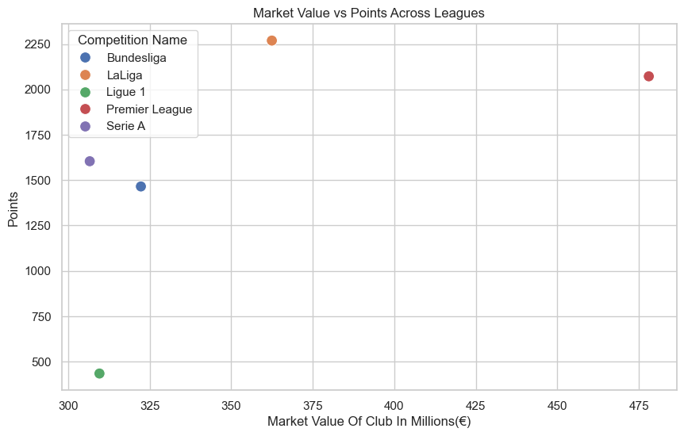

```python
# Market Value vs. Performance (Points)
plt.figure(figsize=(10, 6))
sns.scatterplot(x='Market Value Of Club In Millions(€)', y='Points', hue='Competition Name', data=football, s=100)
plt.title('Market Value vs Points Across Leagues')
plt.xlabel('Market Value Of Club In Millions(€)')
plt.ylabel('Points')
plt.show()
```

The introduction of financial fair play regulations in European football has aimed to limit excessive spending on players. This may have contributed to a less pronounced correlation between market value and points. The quality of a team's manager and their ability to assemble a cohesive squad can have a significant impact on performance, regardless of market value.

Also we need to keep in mind that the points result also from the history of the teams, not just recent results. This tells us that Premier League has both good history and a good financial health in the present.

**Average Salary vs. Performance**

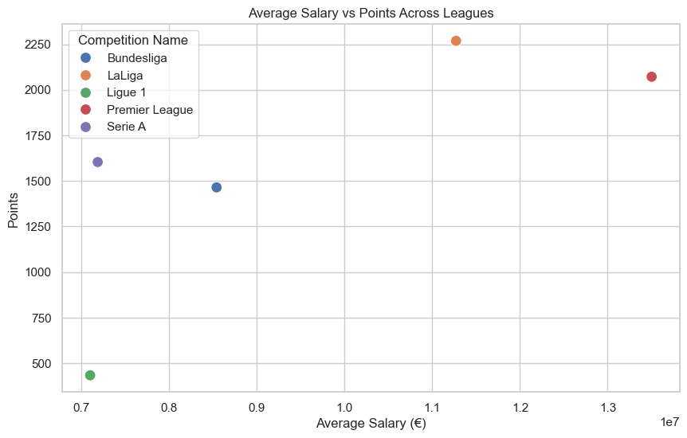

```python
# Average Salary vs. Performance (Points)
plt.figure(figsize=(10, 6))
sns.scatterplot(x='Average Salary (€)', y='Points', hue='Competition Name', data=football, s=100)
plt.title('Average Salary vs Points Across Leagues')
plt.xlabel('Average Salary (€)')
plt.ylabel('Points')
plt.show()
```

**Squad Size and Average Age Across Leagues**

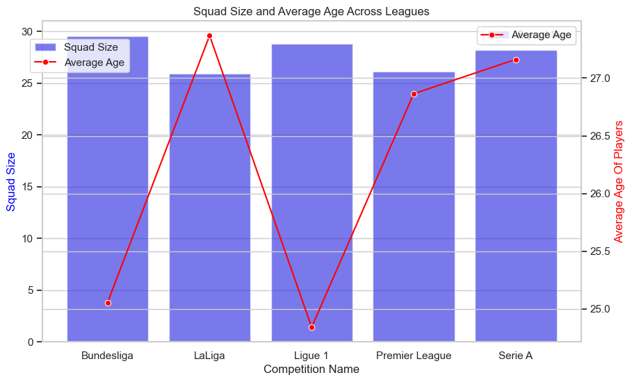

```python
# Squad Size and Average Age Across Leagues
fig, ax1 = plt.subplots(figsize=(10, 6))

sns.barplot(x='Competition Name', y='Squad Size', data=football, ax=ax1, color='blue', alpha=0.6, label='Squad Size')
ax2 = ax1.twinx()
sns.lineplot(x='Competition Name', y='Average Age Of Players', data=football, ax=ax2, color='red', marker='o', label='Average Age')

ax1.set_title('Squad Size and Average Age Across Leagues')
ax1.set_ylabel('Squad Size', color='blue')
ax2.set_ylabel('Average Age Of Players', color='red')

fig.legend(loc='upper left', bbox_to_anchor=(0.1, 0.85))
plt.show()
```

Different leagues may have varying philosophies regarding squad size and player development. Some leagues may prioritize developing young talent, leading to larger squads with younger average ages. The level of competition within a league can also impact squad size and age. Leagues with higher levels of competition may require larger squads to cope with injuries and fixture congestion.

**Bar Chart for Goals vs. Assists per League**

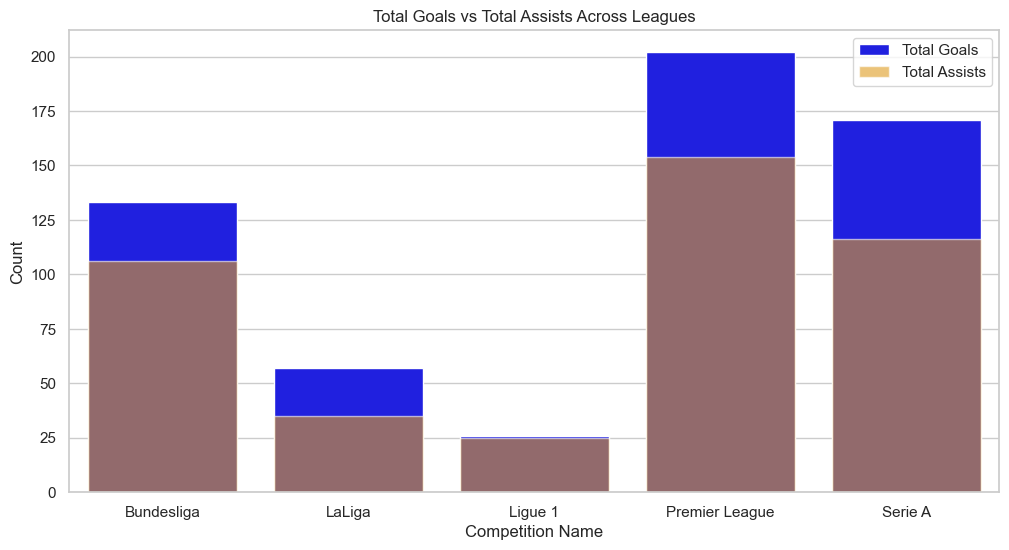

```python
# Bar Chart for Goals vs. Assists per League
plt.figure(figsize=(12, 6))
sns.barplot(x='Competition Name', y='Total Goals', data=football, color='blue', label='Total Goals')
sns.barplot(x='Competition Name', y='Total Assists', data=football, color='orange', label='Total Assists', alpha=0.6)
plt.title('Total Goals vs Total Assists Across Leagues')
plt.ylabel('Count')
plt.legend()
plt.show()
```

Different leagues may have varying styles of play that influence the number of goals and assists. The Premier League is often characterized as a more attacking-focused league, which could contribute to the higher number of goals. Teams in different leagues may employ different tactical approaches that prioritize either goal-scoring or creating chances for others. The overall quality of players in each league can also impact the number of goals and assists. Leagues with a higher concentration of talented attacking players may have higher goal and assist totals.

**Market Value and Average Salary by League**

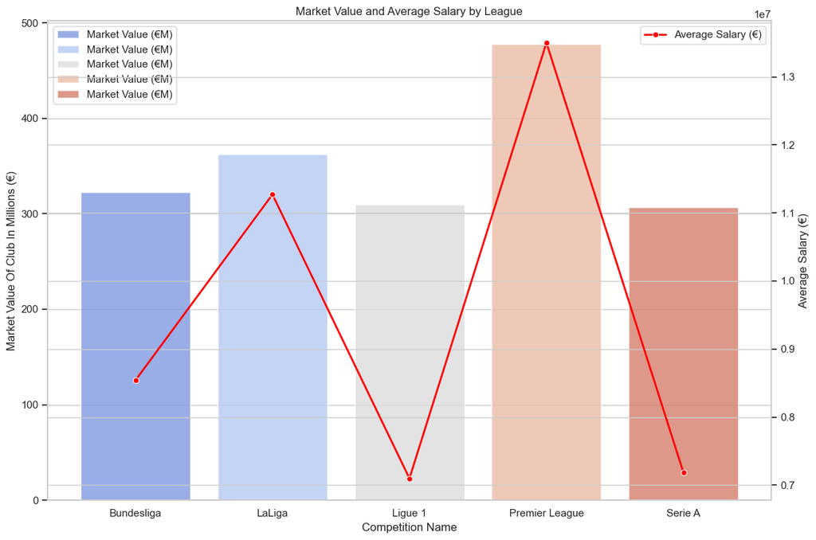

```python
# Set style and color palette
sns.set(style="whitegrid")
palette = sns.color_palette("coolwarm", len(football))

# 1. Bar Plot for Market Value and Line Plot for Average Salary by League
fig, ax1 = plt.subplots(figsize=(12, 8))
ax2 = ax1.twinx()

# Bar plot for Market Value
sns.barplot(x='Competition Name', y='Market Value Of Club In Millions(€)', data=football, ax=ax1, palette=palette, alpha=0.8, label='Market Value (€M)')

# Line plot for Average Salary
sns.lineplot(x='Competition Name', y='Average Salary (€)', data=football, ax=ax2, color='red', marker='o', linewidth=2, label='Average Salary (€)')

# Labeling
ax1.set_ylabel('Market Value Of Club In Millions (€)')
ax2.set_ylabel('Average Salary (€)')
ax1.set_title('Market Value and Average Salary by League')

# Add legends
ax1.legend(loc='upper left')
ax2.legend(loc='upper right')

# Adjust the layout
plt.tight_layout()
plt.show()
```

The Premier League is generally considered to be the wealthiest league, with clubs having access to greater financial resources. This allows them to spend more on players, leading to higher market values and salaries. The Premier League generates significantly higher television revenue compared to other European leagues. This additional income enables clubs to invest more in their squads.

**Goals Scored vs Goals Conceded Across Leagues**

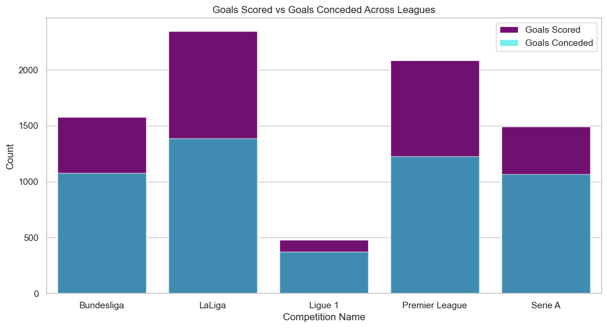

```python
# Bar Chart for Goals Scored vs. Goals Conceded per League
plt.figure(figsize=(12, 6))
sns.barplot(x='Competition Name', y='goals', data=football, color='purple', label='Goals Scored')
sns.barplot(x='Competition Name', y='goal conceded', data=football, color='cyan', label='Goals Conceded', alpha=0.6)
plt.title('Goals Scored vs Goals Conceded Across Leagues')
plt.ylabel('Count')
plt.legend()
plt.show()
```

### Player and performance focused analysis

**Average Market Value vs. Average Age**

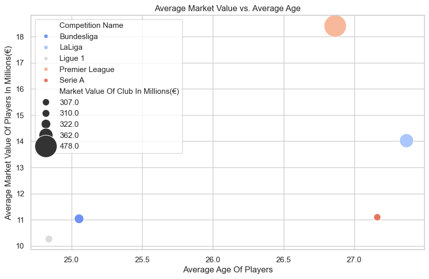

```python
# Scatter Plot for Average Market Value vs. Average Age

# Round the market value sizes to the nearest unit
football['Market Value Of Club In Millions(€)'] = football['Market Value Of Club In Millions(€)'].round()

fig, ax = plt.subplots(figsize=(10, 6))
sns.scatterplot(x='Average Age Of Players', y='Average Market Value Of Players In Millions(€)', hue='Competition Name', size='Market Value Of Club In Millions(€)', sizes=(100, 1000), data=football, palette=palette, ax=ax)
ax.set_title('Average Market Value vs. Average Age')
plt.show()
```

There is no clear correlation between average market value and average age across the leagues. This suggests that teams with higher average market values do not necessarily have older or younger players. This is because market value depends on age, but not necessarily in a linear way. Some players might reach their peak strength around 27 or 28 years old, so their market value might be high, but younger players with potential have also a high market value, despite still not being in their best form. The squad and league composition might vary, so for example Premier League, which is also a more physical demanding league, needs experienced and strong players, who are older. Bundesliga and Ligue 1 have a less physical game, giving young players the opportunity to show off.

**Average Salary vs Total Goals and Average Salary vs Total Assists**

```python
# Scatter plot: Average Salary vs Total Goals
fig1 = px.scatter(
    football,
    x='Average Salary (€)',
    y='Total Goals',
    color='Competition Name',
    trendline='ols',  # Adds a regression line
    title='Average Salary vs Total Goals',
    labels={'Average Salary (€)': 'Average Salary (€)', 'Total Goals': 'Total Goals'}
)

# Scatter plot: Average Salary vs Total Assists
fig2 = px.scatter(
    football,
    x='Average Salary (€)',
    y='Total Assists',
    color='Competition Name',
    trendline='ols',  # Adds a regression line
    title='Average Salary vs Total Assists',
    labels={'Average Salary (€)': 'Average Salary (€)', 'Total Assists': 'Total Assists'}
)

# Show plots
fig1.show()
fig2.show()
```

[output not shown]

This forms a sort of table between leagues, which Premier League always leads, and Ligue 1 is almost always last.

```python
# Scatter plot: Average Salary vs Total Goals
chart1 = alt.Chart(football).mark_point().encode(
    x='Average Salary (€):Q',
    y='Total Goals:Q',
    color='Competition Name:N',
    tooltip=['Competition Name', 'Average Salary (€)', 'Total Goals']
).properties(
    title='Average Salary vs Total Goals'
).interactive()

# Scatter plot: Average Salary vs Total Assists
chart2 = alt.Chart(football).mark_point().encode(
    x='Average Salary (€):Q',
    y='Total Assists:Q',
    color='Competition Name:N',
    tooltip=['Competition Name', 'Average Salary (€)', 'Total Assists']
).properties(
    title='Average Salary vs Total Assists'
).interactive()

# Show charts
chart1 | chart2
```

[interactive chart not shown]

In both plots, there is a weak positive correlation between average salary and total goals/assists. This suggests that teams with higher average salaries tend to have more goals and assists, but the relationship is not strong. Again, Premier League is proven to be a league with money, but also with a lot of quality. Serie A seems to have a good ratio, because in proportion to the salary cost, it has a lot of goals and assists.

### Filtered players

I will now analyze the dataset filtered players, since I already have analyzed clubs in general.

```python
print(filtered_players_data.head().to_string())
```

```
              Name            Position  Age  Country                 Club  Matches  Goals  Assists  Market Value In Millions(€)   Competition Name
0    Kylian Mbappé      Centre-Forward   22   France  Paris Saint-Germain       16      7       11                       168.48  Ligue 1 Uber Eats
1   Erling Haaland      Centre-Forward   21   Norway    Borussia Dortmund       10     13        4                       157.95         Bundesliga
2       Harry Kane      Centre-Forward   28  England    Tottenham Hotspur       16      7        2                       126.36     Premier League
3    Jack Grealish         Left Winger   26  England      Manchester City       15      2        3                       105.30     Premier League
6  Kevin De Bruyne  Attacking Midfield   30  Belgium      Manchester City       14      3        1                       105.30     Premier League
```

**Relationship between player value and performance**

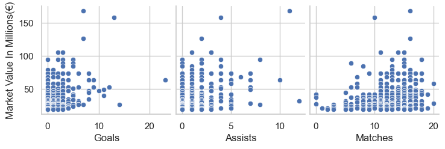

```
                                Goals   Assists   Matches  Market Value In Millions(€)
Goals                        1.000000  0.483735  0.306924                     0.341059
Assists                      0.483735  1.000000  0.405720                     0.346049
Matches                      0.306924  0.405720  1.000000                     0.253226
Market Value In Millions(€)  0.341059  0.346049  0.253226                     1.000000
```

```python
# Relationship between player value and performance
sns.pairplot(filtered_players_data, x_vars=['Goals', 'Assists', 'Matches'], y_vars='Market Value In Millions(€)', kind='scatter')
plt.show()

# Correlation coefficients
correlations = filtered_players_data[['Goals', 'Assists', 'Matches', 'Market Value In Millions(€)']].corr()
print(correlations.to_string())
```

There is a weak positive correlation between market value and goals, assists, and matches. This suggests that players with higher market values tend to have more goals, assists, and matches played, but the relationship is not strong. This is a similar finding to what we stated in the previous section. The data points tend to cluster in certain areas, particularly for goals and assists. This suggests that there are groups of players with similar combinations of market value, goals, and assists and very few players stand out.

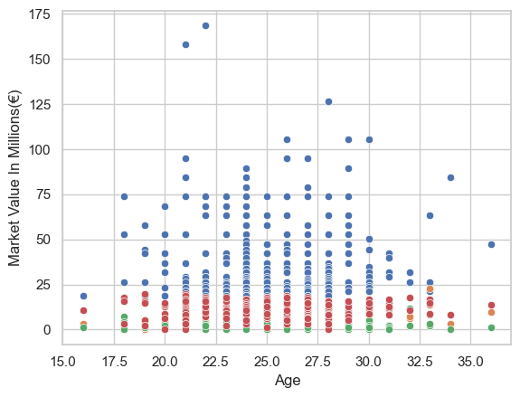

```
                                  Age     Goals   Assists   Matches  Market Value In Millions(€)
Age                          1.000000  0.177867  0.012218  0.028117                    -0.004593
Goals                        0.177867  1.000000  0.483735  0.306924                     0.341059
Assists                      0.012218  0.483735  1.000000  0.405720                     0.346049
Matches                      0.028117  0.306924  0.405720  1.000000                     0.253226
Market Value In Millions(€) -0.004593  0.341059  0.346049  0.253226                     1.000000
```

```python
# Does age influence performance and price?
sns.scatterplot(x='Age', y='Market Value In Millions(€)', data=filtered_players_data)
sns.scatterplot(x='Age', y='Goals', data=filtered_players_data)
sns.scatterplot(x='Age', y='Assists', data=filtered_players_data)
sns.scatterplot(x='Age', y='Matches', data=filtered_players_data)
plt.show()

# Correlation coefficients
age_correlations = filtered_players_data[['Age', 'Goals', 'Assists', 'Matches', 'Market Value In Millions(€)']].corr()
print(age_correlations.to_string())
```

However, none of these correlations seems to be really strong, even if they findings seem to have sense.

**Players' nationality**

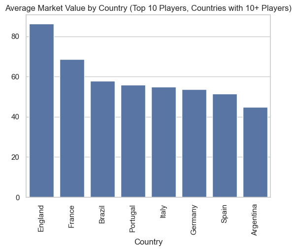

```
ANOVA result for Market Value by Country (Top 10 Players, Countries with 10+ Players): F_onewayResult(statistic=3.3494336865180854, pvalue=0.003803542284019697)
```

```python
# Is there a nation from which players are more expensive?

# Step 1: Filter countries with at least 10 players
country_counts = filtered_players_data['Country'].value_counts()
countries_with_10_or_more = country_counts[country_counts >= 10].index

filtered_data = filtered_players_data[filtered_players_data['Country'].isin(countries_with_10_or_more)]

# Step 2: Sort the data by 'Country' and 'Market Value In Millions(€)' in descending order
sorted_data = filtered_data.sort_values(by=['Country', 'Market Value In Millions(€)'], ascending=[True, False])

# Step 3: Select the top 10 players by market value for each country
top_10_per_country = sorted_data.groupby('Country').head(10)

# Step 4: Group by 'Country' and calculate the mean for 'Market Value In Millions(€)'
country_grouped_top_10 = top_10_per_country.groupby('Country')['Market Value In Millions(€)'].mean().sort_values(ascending=False)

# Step 5: Visualize the average market value by country for the top 10 players
sns.barplot(x=country_grouped_top_10.index, y=country_grouped_top_10.values)
plt.xticks(rotation=90)
plt.title('Average Market Value by Country (Top 10 Players, Countries with 10+ Players)')
plt.show()

# Step 6: ANOVA to test for significant differences between countries
anova_result = f_oneway(*(top_10_per_country[top_10_per_country['Country'] == country]['Market Value In Millions(€)'] for country in top_10_per_country['Country'].unique()))
print('ANOVA result for Market Value by Country (Top 10 Players, Countries with 10+ Players):', anova_result)
```

The strength of the domestic league can influence the market value of players. Leagues with higher levels of competition and exposure may produce players with higher market values. The quality of youth development programs in a country can also impact the development of talented players, leading to higher market values. The dynamics of the transfer market can influence the prices paid for players. Countries with strong footballing cultures and wealthy clubs may be more willing to pay higher transfer fees for top talent, and this is the case of Premier League for example.

**Players' poistion**

```python
# Does position influence price and performance?

# Sort the data by 'Position' and 'Market Value In Millions(€)' in descending order
sorted_data = filtered_players_data.sort_values(by=['Position', 'Market Value In Millions(€)'], ascending=[True, False])

# Select the top 10 players by market value for each position
top_10_per_position = sorted_data.groupby('Position').head(10)

# Group by 'Position' and calculate the mean for 'Market Value In Millions(€)', 'Goals', and 'Assists'
position_grouped_top_10 = top_10_per_position.groupby('Position').agg({
    'Market Value In Millions(€)': 'mean',
    'Goals': 'mean',
    'Assists': 'mean'
}).reset_index()

# Display the results
print(position_grouped_top_10)
```

```
              Position  Market Value In Millions(€)  Goals   Assists
0   Attacking Midfield                      62.0217   3.30  2.700000
1     Central Midfield                      67.9185   2.20  3.500000
2          Centre-Back                      65.8125   0.80  1.200000
3       Centre-Forward                      87.3990   9.40  3.200000
4   Defensive Midfield                      59.3892   1.30  1.200000
5           Goalkeeper                      35.4861   0.00  0.000000
6        Left Midfield                      33.8715   1.50  1.833333
7          Left Winger                      81.9234   4.30  3.200000
8            Left-Back                      43.4889   0.40  1.500000
9       Right Midfield                      20.0070   0.50  0.500000
10        Right Winger                      56.5461   3.60  1.700000
11          Right-Back                      38.5398   0.60  1.100000
12      Second Striker                      33.6960   4.25  4.750000
```

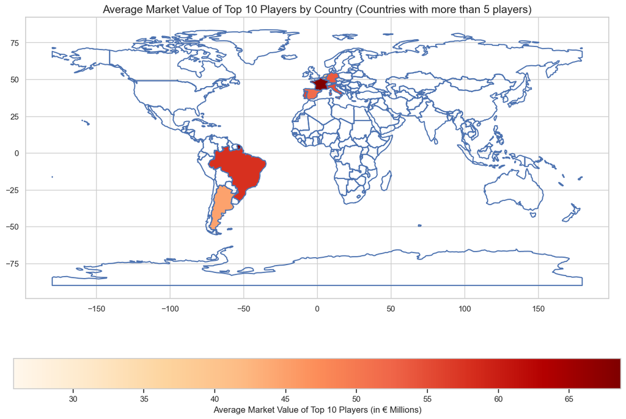

```python
# Step 1: Filter countries with more than 5 players
country_counts = filtered_players_data['Country'].value_counts()
countries_with_more_than_5 = country_counts[country_counts > 5].index

filtered_data = filtered_players_data[filtered_players_data['Country'].isin(countries_with_more_than_5)]

# Step 2: Sort the data by 'Country' and 'Market Value In Millions(€)' in descending order
sorted_data = filtered_data.sort_values(by=['Country', 'Market Value In Millions(€)'], ascending=[True, False])

# Step 3: Select the top 10 players by market value for each country
top_10_per_country = sorted_data.groupby('Country').head(10)

# Step 4: Calculate the average market value for these top 10 players in each country
country_grouped_top_10 = top_10_per_country.groupby('Country')['Market Value In Millions(€)'].mean().reset_index()

# Step 5: Load world map data
world = gpd.read_file(gpd.datasets.get_path('naturalearth_lowres'))

# Step 6: Merge the average market value data with the world map data
world = world.merge(country_grouped_top_10, how='left', left_on='name', right_on='Country')

# Step 7: Plot the map
fig, ax = plt.subplots(1, 1, figsize=(15, 10))
world.boundary.plot(ax=ax)
world.plot(column='Market Value In Millions(€)', ax=ax, legend=True,
           legend_kwds={'label': "Average Market Value of Top 10 Players (in € Millions)",
                        'orientation': "horizontal"}, cmap='OrRd')

# Add a title
plt.title('Average Market Value of Top 10 Players by Country (Countries with more than 5 players)', fontsize=15)
plt.show()
```

Europe is the region with the highest concentration of countries with high average market values, with Spain, Portugal, Italy, France, England, and Germany all ranking in the top 10. South America also has two countries in the top 10, Brazil and Argentina, indicating their strong footballing traditions and ability to produce highly valued players. There are clear geographic disparities in player values. Countries in Europe and South America tend to have higher average market values compared to other regions.

The strength of domestic leagues can influence player development and market values. European leagues, particularly those in England, Spain, Germany, and Italy, are generally considered to be among the strongest in the world, which may contribute to the higher market values of their players and more players of those nationalities to play. Youth Development: The quality of youth development programs in a country can also impact the development of talented players, leading to higher market values. Countries with strong youth academies and infrastructure may be more likely to produce top-level players.

```python
# Assuming 'filtered_players_data' is your DataFrame
country_counts = filtered_players_data['Country'].value_counts()

# Convert the Series to a DataFrame for easier viewing
country_counts_df = country_counts.reset_index()
country_counts_df.columns = ['Country', 'Count']

# Display the DataFrame
print(country_counts_df)
```

```
           Country  Count
0          England     46
1           France     32
2            Spain     30
3            Italy     24
4           Brazil     21
5          Germany     18
6         Portugal     16
7        Argentina     13
8      Netherlands      8
9          Belgium      8
10     Switzerland      6
11         Denmark      5
12          Serbia      5
13         Croatia      5
```

[output cut: 33 more lines]

As we can see from this list, there are a lot of represented countries (47), but only 8 of them have more than 10 players. We also have to keep in mind that this dataset contains information about only 300 players in the top 5 leagues, and they are some of the most valuable. This just depicts the picture of the nationalities with the most valuable players.

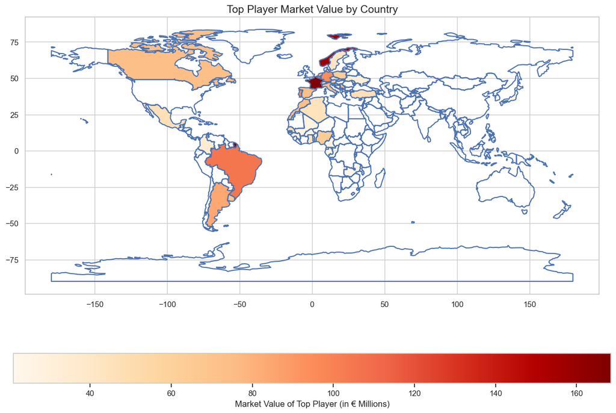

```python
# Step 1: Calculate the market value of the top player for each country

# Sort by 'Country' and 'Market Value In Millions(€)' in descending order
sorted_data = filtered_players_data.sort_values(by=['Country', 'Market Value In Millions(€)'], ascending=[True, False])

# Get the top player for each country
top_players = sorted_data.groupby('Country').first().reset_index()

# Create a DataFrame with country names and top player's market value
top_players_market_value = top_players[['Country', 'Market Value In Millions(€)']]

# Step 2: Load world map data
world = gpd.read_file(gpd.datasets.get_path('naturalearth_lowres'))

# Step 3: Merge the top players market value data with the world map data
# Make sure country names match between the datasets
world = world.rename(columns={'name': 'Country'})
world = world.merge(top_players_market_value, how='left', on='Country')

# Step 4: Plot the map
fig, ax = plt.subplots(1, 1, figsize=(15, 10))
world.boundary.plot(ax=ax)
world.plot(column='Market Value In Millions(€)', ax=ax, legend=True,
           legend_kwds={'label': "Market Value of Top Player (in € Millions)",
                        'orientation': "horizontal"}, cmap='OrRd')

# Add a title
plt.title('Top Player Market Value by Country', fontsize=15)
plt.show()
```

This reflects what we have just seen, with a few additions: there are countries who might not produce many players, but one of them stands out internationally. This is the case of Norway with Erling Haaland or Canada with Alphonso Davies.

### Clubs

Now a brief overview on clubs, which we haven't seen separated from their league yet.

```python
print(clubs5[:10].to_string())
```

```
             Club Name Competition Name  Squad Size  Average Age Of Players  Market Value Of Club In Millions(€)  Average Market Value Of Players In Millions(€)  Market Value Of Top 18 Players In Millions(€)
0      Manchester City   Premier League          24                    27.1                            1134.9234                                         47.2914                                      1077.2190
1  Paris Saint-Germain          Ligue 1          36                    26.1                            1042.6806                                         28.9692                                       937.1700
2    Manchester United   Premier League          29                    27.9                             959.5521                                         33.0876                                       868.7250
3           Chelsea FC   Premier League          27                    26.9                             938.7495                                         34.7724                                       862.4070
4         Liverpool FC   Premier League          27                    27.2                             912.4245                                         33.7896                                       837.6615
5        Bayern Munich       Bundesliga          26                    26.1                             885.0465                                         34.0353                                       849.6657
6          Real Madrid           LaLiga          27                    27.3                             796.0680                                         29.4840                                       713.9340
7   Atlético de Madrid           LaLiga          22                    28.2                             785.4327                                         35.6967                                       762.3720
8    Tottenham Hotspur   Premier League          24                    25.6                             733.9410                                         30.5838                                       652.8600
9         FC Barcelona           LaLiga          30                    25.9                             692.8740                                         23.0958                                       626.5350
```

```python
champions_league_winners = [
    "Real Madrid",       # 2024
    "Manchester City",  # 2023
    "Real Madrid",      # 2022
    "Chelsea FC",          # 2021
    "Bayern Munich",    # 2020
    "Liverpool FC",        # 2019
    "Real Madrid",      # 2018
    "Real Madrid",      # 2017
    "Real Madrid",      # 2016
    "FC Barcelona",        # 2015
    "Real Madrid",      # 2014
    "Bayern Munich",    # 2013
    "Chelsea FC",          # 2012
    "FC Barcelona",        # 2011
    "Inter Milan",      # 2010
]

# Create a mapping of Club Name to Competition Name using the original 'clubs5' DataFrame
club_to_league_mapping = clubs5.set_index('Club Name')['Competition Name'].to_dict()

# Map the champions to their respective competitions
competition_names = [club_to_league_mapping[club] for club in champions_league_winners]

# Count the occurrences of each competition (league)
league_champions_count = pd.Series(competition_names).value_counts()

# Display the result
print(league_champions_count)
```

```
LaLiga            8
Premier League    4
Bundesliga        2
Serie A           1
Name: count, dtype: int64
```

```python
# Select the desired columns
sorted_club_values = clubs_top5l[['Competition Name', 'Market Value Of Club In Millions(€)']]

# Sort by 'Market Value Of Club In Millions(€)'
sorted_club_values = sorted_club_values.sort_values(by='Market Value Of Club In Millions(€)', ascending=False)

# Display the result
print(sorted_club_values)
```

```
  Competition Name  Market Value Of Club In Millions(€)
3   Premier League                           478.016370
1           LaLiga                           362.466900
0       Bundesliga                           322.325100
2          Ligue 1                           309.620610
4          Serie A                           306.644569
```

This proves that money don't buy trophies, at least on average. In fact, now we will take a look at single clubs. Despite LaLiga not being first in market value of clubs, 6 of the last 8 Champions Leagues won by Spanish teams are from Real Madrid.

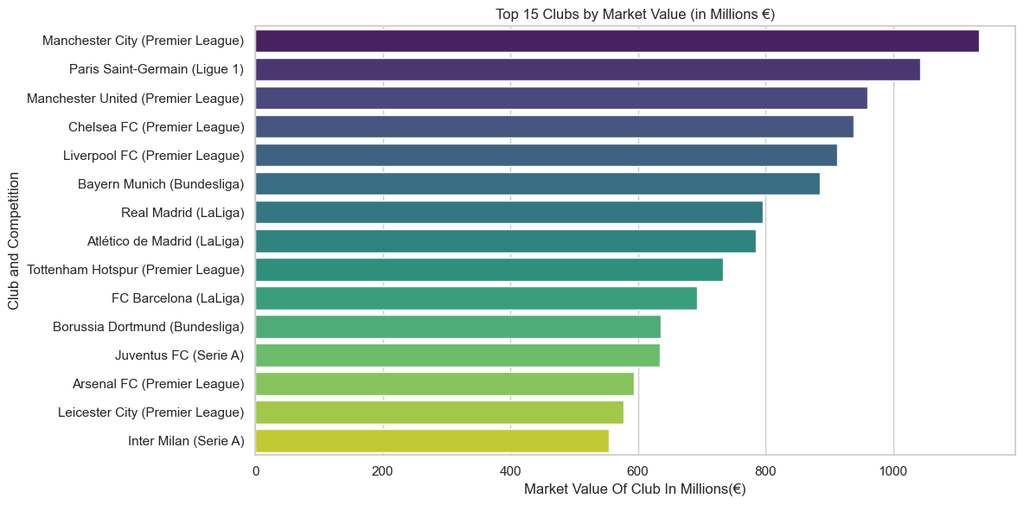

```python
# Sort the DataFrame by 'Market Value Of Club In Millions(€)' in descending order
top_15_clubs = clubs5.sort_values(by='Market Value Of Club In Millions(€)', ascending=False).head(15)

# Create a new column with 'Club Name' and 'Competition Name' in brackets
top_15_clubs['Club and Competition'] = top_15_clubs['Club Name'] + ' (' + top_15_clubs['Competition Name'] + ')'

# Plotting the histogram using a bar plot
plt.figure(figsize=(12, 6))
sns.barplot(
    x='Market Value Of Club In Millions(€)',
    y='Club and Competition',
    data=top_15_clubs,
    palette='viridis'
)

# Set titles and labels
plt.title('Top 15 Clubs by Market Value (in Millions €)')
plt.xlabel('Market Value Of Club In Millions(€)')
plt.ylabel('Club and Competition')

# Show plot
plt.tight_layout()
plt.show()
```

Despite Real Madrid being only 7th in the total table, they still are the team who won the most in the last 10 years. This is because football performance is not always directly correlated to money.

This graphs asserts once again the financial dominance of English football in Europe. We could call Real Madrid an outlier, because for the rest of the findings the clubs' and leagues' values do seem to be related to performance.

## Conclusions

The findings of this notebook perfectly match the initial research purposes. The main findings will be explained below.

The analysis of football clubs and leagues reveals that financial investment does not necessarily equate to success on the field. While the Premier League consistently shows a positive correlation between market value and on-field performance, this trend is not uniformly observed across other major European leagues. Factors such as team chemistry, tactical approaches, and managerial expertise significantly impact a team's success, suggesting that football remains unpredictable and complex despite financial disparities. The weak correlation between market value, goals, assists, and points highlights that high spending does not guarantee top performance, reflecting the impact of strategic planning and individual talent.

Furthermore, the geographical distribution of high-value players underscores the dominance of European and South American countries, bolstered by strong domestic leagues and youth development programs. While financial powerhouses like the Premier League have an advantage, this analysis reinforces that success in football is multifaceted, relying on a combination of financial investment, tactical insight, and the development of talent.